# 机器学习1——分类问题

## 为建模准备数据

在时间场景中，我们一般会另设一个Dev数据集作为开发数据集（测试集），我们在成功建模后用它对模型调优。模型是从训练集中训练出来的，然后用Dev数据来度量它的指标准确度等，基于上述过程的结果，如果需要进一步提高，模型会被更深入的调优。

```python
from sklearn.cross_validation import train_test_split
from sklearn.datasets import load_iris
import numpy as np

def get_iris():
    data=load_iris()
    x=data['data']
    y=data['target']
    input_dataset=np.column_stack([x,y])
    np.random.shuffle(input_dataset)
    return input_dataset
#采用8/2分布分割数据集
data=get_iris()
train,test=train_test_split(data,train_size=0.8)
print("train size",train.shape)
print("test size ",test.shape)

# 检测训练集和测试集的类别标签是否分布合理

def get_class_distribution(y):
    distribution={}
    set_y=set(y)
    for y_label in set_y:
        no_element=len(np.where(y==y_label)[0])
        distribution[y_label]=no_element
    return distribution

def print_class_label_split(train,test):
    y_train=train[:,-1]
    train_distribution=get_class_distribution(y_train)
    print("\nTrain data set class label distribution")
    print("======================================\n")
    for k ,v in train_distribution.items():
        print("class label=%d, Percentage records=%0.2f"%(k,v))

    y_test=test[:,-1]
    test_distribution=get_class_distribution(y_test)
    print("\nTest data set class label distribution")
    print("======================================\n")
    for k ,v in test_distribution.items():
        print("class label=%d, Percentage records=%0.2f"%(k,v))
print_class_label_split(train,test)
```

```
train size (120, 5)
test size  (30, 5)

Train data set class label distribution
======================================

class label=0, Percentage records=36.00
class label=1, Percentage records=42.00
class label=2, Percentage records=42.00

Test data set class label distribution
======================================

class label=0, Percentage records=14.00
class label=1, Percentage records=8.00
class label=2, Percentage records=8.00
```

**如何在训练集和测试集中均匀的分割类别标签**

```python
from sklearn.cross_validation import StratifiedShuffleSplit
straified_split=StratifiedShuffleSplit(data[:,-1],test_size=0.2,n_iter=1)
for train_index,test_index in straified_split:
    train=data[train_index]
    test=data[test_index]
    print_class_label_split(train,test)
```

```
Train data set class label distribution
======================================

class label=0, Percentage records=40.00
class label=1, Percentage records=40.00
class label=2, Percentage records=40.00

Test data set class label distribution
======================================

class label=0, Percentage records=10.00
class label=1, Percentage records=10.00
class label=2, Percentage records=10.00
```

## 查找最近邻

首先需要混淆矩阵，它是类别标签的真实值与预测值的对应排列矩阵。

[output not shown]

准确度是正确的预测总数的总数。从混淆矩阵中，我们知道TP和TN之和就是正确的预测数。$$Accuracy=\frac{Correct Predictions}{Total Predicitons}$$ 训练集的准确度总是比较乐观的，但是我们应该看看测试集的准确度指标来判断模型的真正效果

K近邻算法（KNN）把所有的训练集数据加载到内存中，当它需要对测试实例进行分类时，它衡量这个实例和所有训练实例之间的距离，基于距离，它选择训练集里的K个最近的实例。测试集的分类预测值就是基于这K个最近邻的主体分类情况

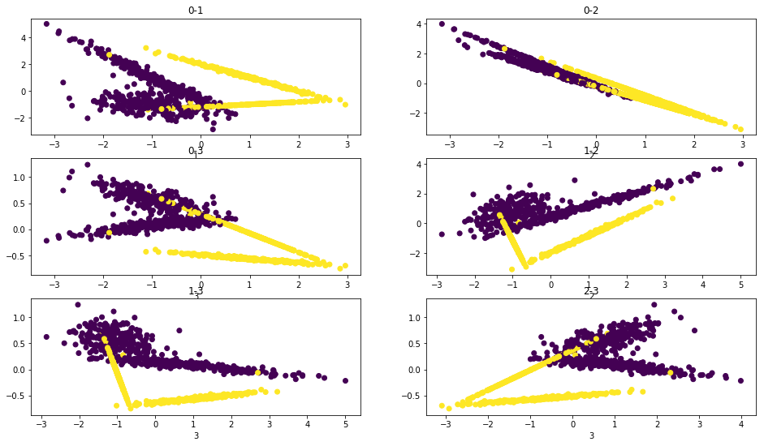

```python
# 准备数据
from sklearn.datasets import make_classification
import numpy as np
import matplotlib.pyplot as plt
import itertools
from sklearn.ensemble import BaggingClassifier
from sklearn.neighbors import KNeighborsClassifier

def get_data():
    x,y=make_classification(n_features=4,n_samples=1000)
    return x,y

def plot_data(x,y):
    """
    Plot a scatter plot fo all variable combinations
    """
    subplot_start = 321
    col_numbers = range(0,4)
    col_pairs = itertools.combinations(col_numbers,2)
    plt.subplots_adjust(wspace=0.36,hspace=0.2)
    plt.figure(figsize=(16,9))
    for col_pair in col_pairs:
        plt.subplot(subplot_start)
        plt.scatter(x[:,col_pair[0]],x[:,col_pair[1]],c=y)
        title_string = str(col_pair[0]) + "-" + str(col_pair[1])
        plt.title(title_string)
        x_label = str(col_pair[0])
        y_label = str(col_pair[1])
        plt.xlabel(x_label)
        plt.xlabel(y_label)
        subplot_start+=1
x,y=get_data()
plot_data(x,y)
```

[output not shown]

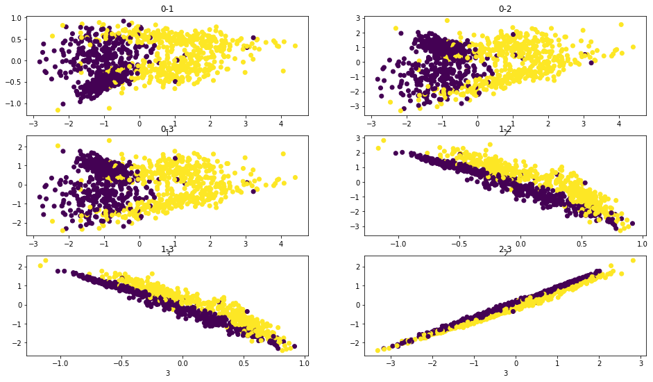

```python
from sklearn.cross_validation import StratifiedShuffleSplit
from sklearn.neighbors import KNeighborsClassifier
from sklearn.metrics import classification_report

def get_train_test(x,y):
    train_size=0.7
    test_size=1-train_size
    input_data=np.column_stack([x,y])
    straified_split=StratifiedShuffleSplit(input_data[:,-1],train_size=train_size,n_iter=1)
    for train_indx,test_indx in straified_split:
        train_x=input_data[train_indx,:-1]
        train_y=input_data[train_indx,-1]
        test_x=input_data[test_indx,:-1]
        test_y=input_data[test_indx,-1]
    return train_x,train_y,test_x,test_y

def build_model(x,y,k=2):
    knn=KNeighborsClassifier(n_neighbors=k)
    knn.fit(x,y)
    return knn
def test_model(x,y,knn_model):
    y_predicted=knn_model.predict(x)
    print(classification_report(y,y_predicted))

x,y=get_data()
plot_data(x,y)
train_x,train_y,test_x,test_y=get_train_test(x,y)
knn_model=build_model(train_x,train_y)
test_model(test_x,test_y,knn_model)
test_model(train_x,train_y,knn_model)
```

## 用朴素贝叶斯分类文档

这种算法的驱动力来自贝叶斯规则，公式如下：$$P(X|Y)=\frac{P(Y|X)*P(X)}{P(Y)}$$ 这个公式展示了我们已经知道事件Y的发生的情况时，事件X发生的概率有多大。在贝叶斯的术语里，必须先定义条件概率：给定评价条件下评价为正面的概率和给定评价条件下评价为负面的概率，写成如下等式：$$P(class=positive|review) and P(class=negative|review)$$ 对于任何一条评价，如果有了上面两个概率值，我们即可通过比较它们来将这条评价归类到正面还是负面：如果负面的条件概率大于正面的条件概率，则评价法是负面分类，反之亦然。$$P(positive|review)=\frac{P(review|positive)*P(positive)}{P(review)}$$ $$P(negative|review)=\frac{P(review|negative)*P(negative)}{P(review)}$$

要比较这两个等式来决定最终结果，我们可以忽略分母，因此它只是简单的缩放因此，等式左边称为后验概率。等式右边的分子部分$P(review|positive)*P(positive)$,其中$P(positive)$是正面评价的先验概率，它是我们从训练集中获取的正面分类标签的分布信仰，我们通过下面的公式把它从训练集中计算出来：$$P(positive)=\frac{No of reviews with positive classl label}{Total reviews in the corpus}$$ $P(review|postive)$是一种可能性，它回答了这个问题：给定这个类别是正面的，这个评价是正面的可能性有多大

```python
#加载库和生成数据
from nltk.corpus import movie_reviews,stopwords
from sklearn.cross_validation import StratifiedShuffleSplit
import nltk
from nltk.collocations import BigramCollocationFinder,BigramAssocMeasures

def get_data():
    dataset=[]
    ylabel=[]
    for cat in movie_reviews.categories():
        for field in movie_reviews.fileids(cat):
            words=list(movie_reviews.words(field))
            dataset.append((words,cat))
            ylabel.append(cat)
    return dataset,ylabel

def get_train_test(input_dataset,ylabel):
    stragiht_split=StratifiedShuffleSplit(ylabel,train_size=0.8,n_iter=1)
    for train_index,test_index in stragiht_split:
        train=[input_dataset[i] for i in train_index]
        train_y=[ylabel[i] for i in train_index]
        test=[input_dataset[i] for i in test_index]
        test_y=[ylabel[i] for i in test_index]
    return train,train_y,test,test_y
```

```python
#模型构建
def build_word_features(instance):
    feature_set={}
    words=instance[0]
    for word in words:
        feature_set[word]=1
    return (feature_set,instance[1])

def build_negate_features(instance):
    words= instance[0]
    final_words=[]
    negate=False
    negate_words=['no','not']
    for word in words:
        if negate:
            word='not_'+word
            negate=False
        if word not in negate_words:
            final_words.append(word)
        else:
            negate=True
    feature_set={}
    for word in final_words:
        feature_set[word]=1
    return (feature_set,instance[1])

def remove_stop_words(in_data):
    stopwordlist=stopwords.words('english')
    negate_words=['no','not']
    New_stopwords=[word for word in stopwordlist if word not in negate_words]
    label=in_data[1]
    words=[word for word in in_data[0] if word not in New_stopwords]
    return (words,label)

def build_keyphrase_features(instance):
    feature_set={}
    instance=remove_stop_words(instance)
    words=instance[0]
    bigram_finder=BigramCollocationFinder.from_words(words)
    bigrams=bigram_finder.nbest(BigramAssocMeasures.raw_freq,400)
    for bigram in bigrams:
        feature_set[bigram]=1
    return (feature_set,instance[1])

def build_model(features):
    model=nltk.NaiveBayesClassifier.train(features)
    return model

def probel_model(model,features,dataset_type='Train'):
    accuracy=nltk.classify.accuracy(model,features)
    print("\n"+ dataset_type+"Accuracy=%0.2f"%(accuracy*100)+"%")

def show_features(model,features=5):
    print("\nFeature Importance")
    print("=====================")
    print(model.show_most_informative_features(features))
```

```python
#模型调整
def build_model_cycle_1(train_data,dev_data):
    train_features=map(build_word_features,train_data)
    dev_features=map(build_negate_features,dev_data)
    model=build_model(train_features)
    probel_model(model,train_features)
    probel_model(model,dev_features,"Dev")
    return model
def build_model_cycle_2(train_data,dev_data):
    train_features=map(build_word_features,train_data)
    dev_features=map(build_negate_features,dev_data)
    model=build_model(train_features)
    probel_model(model,train_features)
    probel_model(model,dev_features,"Dev")
    return model
def build_model_cycle_3(train_data,dev_data):
    train_features=map(build_word_features,train_data)
    dev_features=map(build_negate_features,dev_data)
    model=build_model(train_features)
    probel_model(model,train_features)
    probel_model(model,dev_features,"Dev")
    return model
```

```python
#主程序
input_dataset,ylabels=get_data()
train_data,train_y,ALL_test_data,ALL_test_y=get_train_test(input_dataset,ylabels)
dev_data,dev_y,test_data,test_y=get_train_test(ALL_test_data,ALL_test_y)
print("\n Origin Data Size=",len(input_dataset))
print("\n Train Data Size=",len(train_data))
print("\n Dev Data Size=",len(dev_data))
print("]n Test Data Size=",len(test_data))

model_cycle_1=build_model_cycle_1(train_data,dev_data)
show_features(model_cycle_1)
model_cycle_2=build_model_cycle_2(train_data,dev_data)
show_features(model_cycle_2)
model_cycle_3=build_model_cycle_3(train_data,dev_data)
show_features(model_cycle_3)
```

```
 Origin Data Size= 2000

 Train Data Size= 1600

 Dev Data Size= 160
]n Test Data Size= 20

TrainAccuracy=0.00%

DevAccuracy=0.00%

Feature Importance
=====================
Most Informative Features
                   sucks = 1                 neg : pos    =     16.3 : 1.0
                   lousy = 1                 neg : pos    =     13.7 : 1.0
                  seagal = 1                 neg : pos    =     11.7 : 1.0
             outstanding = 1                 pos : neg    =     11.4 : 1.0
               stupidity = 1                 neg : pos    =     11.0 : 1.0
None

TrainAccuracy=0.00%

DevAccuracy=0.00%

Feature Importance
=====================
Most Informative Features
                   sucks = 1                 neg : pos    =     16.3 : 1.0
                   lousy = 1                 neg : pos    =     13.7 : 1.0
                  seagal = 1                 neg : pos    =     11.7 : 1.0
             outstanding = 1                 pos : neg    =     11.4 : 1.0
               stupidity = 1                 neg : pos    =     11.0 : 1.0
None

TrainAccuracy=0.00%

DevAccuracy=0.00%

Feature Importance
=====================
Most Informative Features
                   sucks = 1                 neg : pos    =     16.3 : 1.0
                   lousy = 1                 neg : pos    =     13.7 : 1.0
                  seagal = 1                 neg : pos    =     11.7 : 1.0
             outstanding = 1                 pos : neg    =     11.4 : 1.0
               stupidity = 1                 neg : pos    =     11.0 : 1.0
None
```

## 构建决策树解决多类问题

理论上，对于给定的决策树可以构建许多决策树，其中一些的准确度要更好一些。现在有一些高效的算法，能够有限的时间内生成较为合理准确的树。比如Hunt算法，ID3，C4.5和CART等算法都是基于它而来的，这种算法的概述如下：

给定一个数据集D，他有n条记录，每条记录具有每个属性，而且每条记录的标签为y1,y2,y3三者中的一个。算法过程如下

- 如果D里的所有记录都属于同一个类别，假定为y1,则y1是树的叶子节点，标签为y1
- 如果D的记录属于多个类别，则采用一个特征测试条件将记录分割成较小的子集。假定第一次运行，我们在所有的属性上执行特征测试条件，从中找出一个属性能够把数据字分割成为3个较小的子集，然后将这个属性变成根节点，在3个子集中应用测试条件来找出下一级节点。这个过程不断迭代执行

决策树有许多的有点，列举如下：

- 易于解释
- 仅需要极少的数据准备和数据-特征转换
- 天然支持多分类问题

决策树也有自己的不足：

- 容易过拟合：训练集的准确度很高而对测试集的效果很差
- 对于一个给定的数据集，能产生成千上万的决策树
- 类别不平衡的影响十分严重：在二元分类问题中，每类的实例数量不同时就会爆发类别不平衡，对多分类问题也是一样

特征测试条件就是基于一个称为“不纯性”的标准或指标，将输入的记录分割成多个自己。不纯性则是通过对实例的每个属性上的类别标签进行相关的计算得出，对它影响最大的属性被分割为数据的基准属性。也就是树里的这一级节点。在决策树中，采用“熵”的概念作为计算不纯度的指标。熵的定义如下$$E(X)=-\sum_{i=1}^{n}{P(x_i)log_2{P(x_i)}}$$ 其中$P(x_i)$的定义如下：$$P(x_i)=\frac{Count of x_i}{length(X)}$$

为了找到最适合用来分割数据的变量，我们选择了熵，首先要做的就是基于类别标签对熵进行计算，公式如下：$$Entropy(t)=-\sum_{i=0}^{c-1}{p(i|t)log_2{p(i|t)}}$$

```python
from sklearn.datasets import load_iris
from sklearn.cross_validation import StratifiedShuffleSplit
import numpy as np
from sklearn import tree
from sklearn.metrics import accuracy_score,classification_report,confusion_matrix
import pprint

def get_data():
    data=load_iris()
    x=data['data']
    y=data['target']
    label_names=data['target_names']
    return x,y,label_names.tolist()
def get_feature_names():
    data=load_iris()
    x_feature=data['feature_names']
    return data['feature_names']
def get_train_test(x,y):
    input_data=np.column_stack([x,y])
    straight_split=StratifiedShuffleSplit(input_data[:,-1],train_size=0.7,n_iter=1,random_state=77)
    for train_index,test_index in straight_split:
        train_x=input_data[train_index,:-1]
        train_y=input_data[train_index,-1]
        test_x=input_data[test_index,:-1]
        test_y=input_data[test_index,-1]
        print(train_x.shape)
        print(test_x.shape)
    return train_x,train_y,test_x,test_y

def build_model(x,y):
    model=tree.DecisionTreeClassifier(criterion="entropy")
    model=model.fit(x,y)
    return model

def test_model(x,y,model,label_names):
    y_predicted=model.predict(x)
    print("Model Accuracy = %0.2f" %(accuracy_score(y,y_predicted)*100),"%\n")
    print("\n Confusion Matrix")
    print('====================')
    print(pprint.pprint(confusion_matrix(y,y_predicted)))
    print('\nClassification Report')
    print('========================')
    print(classification_report(y,y_predicted,target_names=label_names))

x,y,label_names=get_data()
train_x,train_y,test_x,test_y=get_train_test(x,y)
model=build_model(train_x,train_y)
test_model(test_x,test_y,model,label_names)
tree.export_graphviz(model,out_file='tree.dot',feature_names=get_feature_names(),class_names=label_names)#指定特征值标签和类标签
```

```
(105, 4)
(15, 4)
Model Accuracy = 93.33 %


 Confusion Matrix
====================
array([[5, 0, 0],
       [0, 4, 1],
       [0, 0, 5]], dtype=int64)
None

Classification Report
========================
             precision    recall  f1-score   support

     setosa       1.00      1.00      1.00         5
 versicolor       1.00      0.80      0.89         5
  virginica       0.83      1.00      0.91         5

avg / total       0.94      0.93      0.93        15
```

```python
%%cmd
dot -Tpdf tree.dot -o tree.pdf
```

```
Microsoft Windows [版本 10.0.16299.371]
(c) 2017 Microsoft Corporation。保留所有权利。

E:\PycharmProjects\JupyterFiles\python>dot -Tpdf tree.dot -o tree.pdf

E:\PycharmProjects\JupyterFiles\python>
```

# 机器学习2——回归问题

回归可以被认为是一种函数逼近，它的任务是找到这样一个函数：当一系列随机变量X作为函数的输入时，返回反应变量Y。简单回归框架虽然威力强大，但是仍然你手指与一个缺陷：由于线性回归采用的系数值上限和下限无法控制，对于给定的数据，回归容易过度拟合。对于未知数据，输出的回归模型可能执行效果不佳，缩减方法就是用来解决这个问题的，它也被称为正则化方法。

## 回归方法预测实数值

一个线性回归模型的定义如下：使用训练集数据来查找系数$$w=(w_1,w_2...,w_m)$$使得$$\sum_{i=1}^{n}{(y_i-\sum_{j=0}^{m}{x_j*w_j})^2}$$这个式子的值尽量小。

这个等式的值越小，线性回归模型的效果越号，因此，这个优化问题就是使得上面的等式最小化，也就是说找出使得等式最小的$w_i$系数。$$\frac{1}{n}*\sum_{i=1}^{n}{(y_{true}-y_predicted)^2}$$ 上面这个式子叫做均方误差——用它来衡量回归模型是否可用。我们希望输出模型的真实和预测值的平均平方差尽可能小，这种查找系数的方法叫做最小二乘估计

```python
from sklearn.datasets import load_boston
from sklearn.cross_validation import train_test_split
from sklearn.linear_model import LinearRegression
from sklearn.metrics import mean_squared_error
import matplotlib.pyplot as plt
from sklearn.preprocessing import PolynomialFeatures

def get_data():
    data=load_boston()
    x=data['data']
    y=data['target']
    return x,y

def build_model(x,y):
    model=LinearRegression(normalize=True,fit_intercept=True)
    model.fit(x,y)
    return model
def model_view(model):
    print("\n Model Coefficents")
    print("======================")
    for i,coef in enumerate(model.coef_):
        print("\tCoefficients %d %0.3f" %(i+1,coef))
    print("\n\t Intercept %0.3f" %(model.intercept_))
def model_worth(true_y,predicted_y):
    print("\tMean squared error = %0.2f" %(mean_squared_error(true_y,predicted_y)))

def plot_residuals(y,predicted_y):
    diff=y-predicted_y
    plt.xlabel('Predicted_Y')
    plt.ylabel("Residuals")
    plt.plot(predicted_y,diff,'go')
```

```
 Model Coefficents
======================
	Coefficients 1 -0.109
	Coefficients 2 0.043
	Coefficients 3 0.053
	Coefficients 4 2.237
	Coefficients 5 -15.879
	Coefficients 6 3.883
	Coefficients 7 0.001
	Coefficients 8 -1.321
	Coefficients 9 0.284
	Coefficients 10 -0.012
	Coefficients 11 -0.904
	Coefficients 12 0.009
	Coefficients 13 -0.529

	 Intercept 33.288

Model Performance On Train_set
	Mean squared error = 23.18

Model Performance On Dev_set
	Mean squared error = 18.25
```

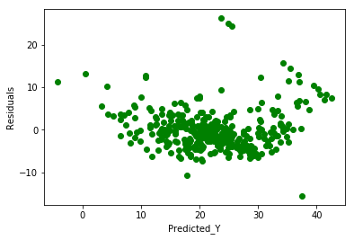

```python
#主程序
x,y=get_data()
x_train,x_test_all,y_train,y_test_all=train_test_split(x,y,test_size=0.3,random_state=9)
x_dev,x_test,y_dev,y_test=train_test_split(x_test_all,y_test_all,test_size=0.3,random_state=9)

model=build_model(x_train,y_train)
predicted_y=model.predict(x_train)
plot_residuals(y_train,predicted_y)
model_view(model)
print("\nModel Performance On Train_set")
model_worth(y_train,predicted_y)
predicted_y=model.predict(x_dev)
print("\nModel Performance On Dev_set")
model_worth(y_dev,predicted_y)
```

```python
# 准备一些多项式特征
poly_features=PolynomialFeatures(2)
poly_features.fit(x_train)
x_train_poly=poly_features.transform(x_train)
x_dev_poly=poly_features.transform(x_dev)

#用多项式特征建模
model_poly=build_model(x_train_poly,y_train)
predicted_y=model_poly.predict(x_train_poly)
print("\nModel Performance On Train_set(poly_features)")
model_worth(y_train,predicted_y)

predicted_y=model_poly.predict(x_dev_poly)
print("\nModel Performance On Dev_set(Poly_features)")
model_worth(y_dev,predicted_y)
```

```
Model Performance On Train_set(poly_features)
	Mean squared error = 5.45

Model Performance On Dev_set(Poly_features)
	Mean squared error = 13.23
```

```python
#将模型应用到测试集上
x_test_poly=poly_features.transform(x_test)
predicted_y=model_poly.predict(x_test_poly)
print("\nModel Performance On Test_set(poly_features)")
model_worth(y_test,predicted_y)

predicted_y=model.predict(x_test)
print("\nModel Performance On Test_set(Regular_features)")
model_worth(y_test,predicted_y)
```

```
Model Performance On Test_set(poly_features)
	Mean squared error = 15.17

Model Performance On Test_set(Regular_features)
	Mean squared error = 21.66
```

## L2缩减回归——岭回归

在训练线性回归模型时，有的系数取值会很大，导致模型很不稳定。正则化或者缩减是控制系数权重的一种途径，这样的权重不会使用过大的数值。如果数据集中包含着大量关联的预测器，仅仅微笑的改变就可能导致模型不稳定。此外，我们还要面对如何解释模型的问题。例如，假定有两个负相关的变量，他们对反应变量的影响应该是相反的。我们可以对相关联的变量进行手工检查，并删除其中其主导因素的变量。然后再进行进行建模，当然如果能够自动完成这些操作，将会方便很多。

我们把线性回归的代价函数进行修改，将系数包含进来，如你所知，代价函数的值最小，模型的效果才好。将系数引入到代价函数之后，可以对权重取值太高的系数进行大幅惩罚。这种方法称为缩减方法，因为他们减小了系数的值。$$\sum_{i=1}^{n}{(y_i-w_0-\sum_{j=1}^{m}{x_{ij}w{ij}})^2+\alpha\sum_{j=1}^{m}{w_{j}^{2}}}$$ 如你所见，代价函数里增加了系数的平方和。这样，在优化过程查找上式最小值的过程中，它必须大大减小系数的值来达到目标。参数$\alpha$决定了缩减的幅度，$\alpha$越大，缩减的幅度越大，系数的值越趋向于0

```python
from sklearn.datasets import load_boston
from sklearn.cross_validation import train_test_split
from sklearn.linear_model import Ridge
from sklearn.metrics import mean_squared_error
from sklearn.preprocessing import PolynomialFeatures
import numpy as np

def get_data():
    data=load_boston()
    x=data['data']
    y=data['target']
    x=x-np.mean(x,axis=0)
    return x,y

def build_model(x,y):
    model=Ridge(normalize=True,alpha=0.015)
    model.fit(x,y)
    return model

def model_view(model):
    print("\n Model Coefficents")
    print("======================")
    for i,coef in enumerate(model.coef_):
        print("\tCoefficients %d %0.3f" %(i+1,coef))
    print("\n\t Intercept %0.3f" %(model.intercept_))
def model_worth(true_y,predicted_y):
    print("\tMean squared error = %0.2f" %(mean_squared_error(true_y,predicted_y)))
    return mean_squared_error(true_y,predicted_y)

x,y=get_data()
x_train,x_test_all,y_train,y_test_all=train_test_split(x,y,test_size=0.3,random_state=9)
x_dev,x_test,y_dev,y_test=train_test_split(x_test_all,y_test_all,test_size=0.3,random_state=9)

#准备一些多项式特征
poly_features=PolynomialFeatures(interaction_only=True)
poly_features.fit(x_train)
x_train_poly=poly_features.transform(x_train)
x_dev_poly=poly_features.transform(x_dev)
x_test_poly=poly_features.transform(x_test)

choosen_model=build_model(x_train_poly,y_train)

#应用模型到测试集
predicted_y=choosen_model.predict(x_train_poly)
print("\nModel Performance in Training set(Poly_features)")
mse=model_worth(y_train,predicted_y)
model_view(choosen_model)

#应用模型到Dev
predicted_y=choosen_model.predict(x_dev_poly)
print("\nModel Performance in Dev set(Poly_features)")
mse=model_worth(y_dev,predicted_y)

#应用模型到测试集
predicted_y=choosen_model.predict(x_test_poly)
print("\nModel Performance in Test set(Poly_features)")
mse=model_worth(y_test,predicted_y)
```

```
Model Performance in Training set(Poly_features)
	Mean squared error = 6.85

 Model Coefficents
======================
	Coefficients 1 0.000
	Coefficients 2 -0.016
	Coefficients 3 -0.003
	Coefficients 4 0.006
	Coefficients 5 4.285
	Coefficients 6 -10.623
	Coefficients 7 5.401
	Coefficients 8 -0.050
	Coefficients 9 -1.361
	Coefficients 10 0.103
	Coefficients 11 -0.009
	Coefficients 12 -0.209
	Coefficients 13 0.018
	Coefficients 14 -0.408
	Coefficients 15 0.003
	Coefficients 16 -0.004
	Coefficients 17 2.027
	Coefficients 18 -0.535
	Coefficients 19 0.156
	Coefficients 20 0.001
	Coefficients 21 -0.044
	Coefficients 22 -0.006
	Coefficients 23 -0.000
	Coefficients 24 0.006
	Coefficients 25 -0.000
	Coefficients 26 0.016
	Coefficients 27 0.002
	Coefficients 28 -0.066
	Coefficients 29 0.035
	Coefficients 30 -0.004
	Coefficients 31 -0.001
	Coefficients 32 0.006
	Coefficients 33 0.003
	Coefficients 34 0.000
	Coefficients 35 -0.000
```

[output cut: 50 more lines]

```
	Coefficients 86 -0.029
	Coefficients 87 0.004
	Coefficients 88 -0.000
	Coefficients 89 -0.001
	Coefficients 90 -0.002
	Coefficients 91 0.031
	Coefficients 92 -0.001

	 Intercept 21.027

Model Performance in Dev set(Poly_features)
	Mean squared error = 11.54

Model Performance in Test set(Poly_features)
	Mean squared error = 9.46
```

## L1缩减回归——LASSO

最小绝对值和选择操作（LASSO）是另一种在回归问题中常用的缩减方法。它和岭回归相比，更倾向于稀疏的结果。如果一个结果的大多数系数被缩减为0，那它被称为稀疏的。LASSO的大多数系数都变成了0，对于相关联的变量，只选择保留其中一个，而不像岭回归那样给这些变量的系数分配相同的权重。LASSO的这种特性可以用来选择变量。$$\sum_{i=1}^{n}{(y_i-w_0-\sum_{j=1}^{m}{x_{ij}w{ij}})^2+\alpha\sum_{j=1}^{m}|{w_{j}^{2}}}|$$

```
Predicting using all the variables
	Mean squared error = 21.90

Models at different alpha values
	 Attributes include [5, 12]
	Mean squared error = 30.51
	 Attributes include [5, 10, 12]
	Mean squared error = 27.13
	 Attributes include [0, 1, 3, 4, 5, 7, 10, 11, 12]
	Mean squared error = 22.89
```

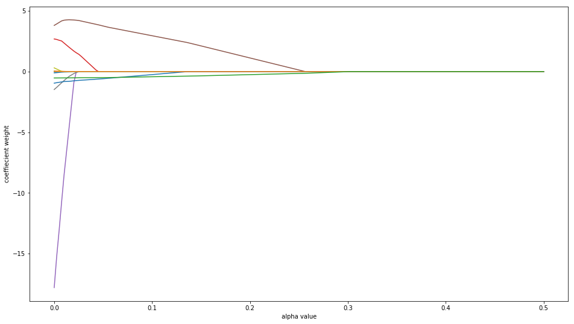

```python
from sklearn.datasets import load_boston
from sklearn.cross_validation import train_test_split
from sklearn.linear_model import Lasso,LinearRegression
from sklearn.metrics import mean_squared_error
from sklearn.preprocessing import PolynomialFeatures
import numpy as np
import matplotlib.pyplot as plt

def get_data():
    data=load_boston()
    x=data['data']
    y=data['target']
    return x,y

def build_model(x,y):
    alpha_range=np.linspace(0,0.5,200)

    model=Lasso(normalize=True)
    coeffiecients=[]
    for alpha in alpha_range:
        model.set_params(alpha=alpha)
        model.fit(x,y)
        coeffiecients.append(model.coef_)
    coeff_path(alpha_range,coeffiecients)

def model_view(model):
    print("\n Model Coefficents")
    print("======================")
    for i,coef in enumerate(model.coef_):
        print("\tCoefficients %d %0.3f" %(i+1,coef))
    print("\n\t Intercept %0.3f" %(model.intercept_))

def model_worth(true_y,predicted_y):
    print("\tMean squared error = %0.2f" %(mean_squared_error(true_y,predicted_y)))
    return mean_squared_error(true_y,predicted_y)

def coeff_path(alpha_range,coeffiecients):
    plt.figure(figsize=(16,9))
    plt.xlabel("alpha value")
    plt.ylabel("coeffiecient weight")
    plt.plot(alpha_range,coeffiecients)
    plt.axis('tight')

def get_coeff(x,y,alpha):
    model=Lasso(normalize=True,alpha=alpha)
    model.fit(x,y)
    coefs=model.coef_
    indices=[i for i,coef in enumerate(coefs) if abs(coef)>0.0]
    return indices

x,y=get_data()
build_model(x,y)
print("\nPredicting using all the variables")

full_model=LinearRegression(normalize=True)
full_model.fit(x,y)
predicted_y=full_model.predict(x)
model_worth(y,predicted_y)

print("\nModels at different alpha values")
alpha_values=[0.22,0.08,0.01]
for alpha in alpha_values:
    indices=get_coeff(x,y,alpha)
    print("\t Attributes include",indices)
    x_new=x[:,indices]
    model=LinearRegression(normalize=True)
    model.fit(x_new,y)
    predicted_y=model.predict(x_new)
    model_worth(y,predicted_y)
```

## L1和L2缩减交叉验证迭代

交叉验证一般也叫K折交叉验证，训练集被划分为k粉，模型在k-1份数据上进行训练，剩下的用来测试，这样就不需要单独划分Dev集

```python
from sklearn.datasets import load_iris
from sklearn.cross_validation import KFold,StratifiedKFold

def get_data():
    data=load_iris()
    x=data['data']
    y=data['target']
    return x,y

def class_distribution(y):
    class_dist={}
    total=0
    for entry in y:
        try:
            class_dist[entry]+=1
        except KeyError:
            class_dist[entry]=1
        total+=1
    for k,v in class_dist.items():
        print('\tclass %d percentage = %0.2f'%(k,v/(1.0*total)))
#第一种分法
x,y=get_data()
kfolds=KFold(n=y.shape[0],n_folds=3)
fold_count=1
for train,test in kfolds:
    print("Fold %d x train shape" %(fold_count),x[train].shape,'x test shape',x[test].shape)
    y_train=y[train]
    y_test=y[test]
    print("Train Class Distribution")
    class_distribution(y_train)
    print("Test Class Distribution")
    class_distribution(y_test)
    fold_count +=1

#第二种分法
skfolds=StratifiedKFold(y,n_folds=3)
fold_count=1
for train,test in skfolds:
    print("Fold %d x train shape" %(fold_count),x[train].shape,'x test shape',x[test].shape)
    y_train=y[train]
    y_test=y[test]
    print("Train Class Distribution")
    class_distribution(y_train)
    print("Test Class Distribution")
    class_distribution(y_test)
    fold_count +=1
```

```
Fold 1 x train shape (100, 4) x test shape (50, 4)
Train Class Distribution
	class 1 percentage = 0.50
	class 2 percentage = 0.50
Test Class Distribution
	class 0 percentage = 1.00
Fold 2 x train shape (100, 4) x test shape (50, 4)
Train Class Distribution
	class 0 percentage = 0.50
	class 2 percentage = 0.50
Test Class Distribution
	class 1 percentage = 1.00
Fold 3 x train shape (100, 4) x test shape (50, 4)
Train Class Distribution
	class 0 percentage = 0.50
	class 1 percentage = 0.50
Test Class Distribution
	class 2 percentage = 1.00
Fold 1 x train shape (99, 4) x test shape (51, 4)
Train Class Distribution
	class 0 percentage = 0.33
	class 1 percentage = 0.33
	class 2 percentage = 0.33
Test Class Distribution
	class 0 percentage = 0.33
	class 1 percentage = 0.33
	class 2 percentage = 0.33
Fold 2 x train shape (99, 4) x test shape (51, 4)
Train Class Distribution
	class 0 percentage = 0.33
	class 1 percentage = 0.33
	class 2 percentage = 0.33
Test Class Distribution
	class 0 percentage = 0.33
	class 1 percentage = 0.33
	class 2 percentage = 0.33
Fold 3 x train shape (102, 4) x test shape (48, 4)
Train Class Distribution
	class 0 percentage = 0.33
	class 1 percentage = 0.33
	class 2 percentage = 0.33
Test Class Distribution
	class 0 percentage = 0.33
	class 1 percentage = 0.33
	class 2 percentage = 0.33
```

```python
from sklearn.datasets import load_boston
from sklearn.cross_validation import KFold,train_test_split
from sklearn.linear_model import Ridge
from sklearn.grid_search import GridSearchCV
from sklearn.metrics import mean_squared_error
from sklearn.preprocessing import PolynomialFeatures
import numpy as np

def get_data():
    data=load_iris()
    x=data['data']
    y=data['target']
    return x,y

def build_model(x,y):
    kfold=KFold(y.shape[0],5)
    model=Ridge(normalize=True)

    alpha_range=np.linspace(0.0015,0.0017,30)
    grid_param={'alpha':alpha_range}
    grid=GridSearchCV(estimator=model,param_grid=grid_param,cv=kfold,scoring='mean_squared_error')
    grid.fit(x,y)
    display_param_results(grid.grid_scores_)
    print(grid.best_params_)
    return grid.best_estimator_

def view_model(model):
    print("\n Model Coefficents")
    print("======================")
    for i,coef in enumerate(model.coef_):
        print("\tCoefficients %d %0.3f" %(i+1,coef))
    print("\n\t Intercept %0.3f" %(model.intercept_))


def model_worth(true_y,predicted_y):
    print("\tMean squared error = %0.2f" %(mean_squared_error(true_y,predicted_y)))
    return mean_squared_error(true_y,predicted_y)

def display_param_results(param_results):
    fold=1
    for param_result in param_results:
        print("Fold %d mean squared error %0.2f" %(fold,abs(param_result[1])),param_result[0])
        fold+=1
```

```python
x,y=get_data()
x_train,x_test,y_train,y_test=train_test_split(x,y,test_size=0.3,random_state=9)

#准备一些多项式特征
poly_features=PolynomialFeatures(interaction_only=True)
poly_features.fit(x_train)
x_train_poly=poly_features.transform(x_train)
x_test_poly=poly_features.transform(x_test)

choosen_model=build_model(x_train_poly,y_train)
predicted_y=choosen_model.predict(x_train_poly)
model_worth(y_train,predicted_y)

view_model(choosen_model)

predicted_y=choosen_model.predict(x_test_poly)
model_worth(y_test,predicted_y)
```

```
Fold 1 mean squared error 0.05 {'alpha': 0.0015}
Fold 2 mean squared error 0.05 {'alpha': 0.001506896551724138}
Fold 3 mean squared error 0.05 {'alpha': 0.0015137931034482758}
Fold 4 mean squared error 0.05 {'alpha': 0.001520689655172414}
Fold 5 mean squared error 0.05 {'alpha': 0.0015275862068965518}
Fold 6 mean squared error 0.05 {'alpha': 0.0015344827586206897}
Fold 7 mean squared error 0.05 {'alpha': 0.0015413793103448276}
Fold 8 mean squared error 0.05 {'alpha': 0.0015482758620689655}
Fold 9 mean squared error 0.05 {'alpha': 0.0015551724137931034}
Fold 10 mean squared error 0.05 {'alpha': 0.0015620689655172415}
Fold 11 mean squared error 0.05 {'alpha': 0.0015689655172413794}
Fold 12 mean squared error 0.05 {'alpha': 0.0015758620689655172}
Fold 13 mean squared error 0.05 {'alpha': 0.0015827586206896551}
Fold 14 mean squared error 0.05 {'alpha': 0.001589655172413793}
Fold 15 mean squared error 0.05 {'alpha': 0.001596551724137931}
Fold 16 mean squared error 0.05 {'alpha': 0.001603448275862069}
Fold 17 mean squared error 0.05 {'alpha': 0.001610344827586207}
Fold 18 mean squared error 0.05 {'alpha': 0.0016172413793103448}
Fold 19 mean squared error 0.05 {'alpha': 0.0016241379310344827}
Fold 20 mean squared error 0.05 {'alpha': 0.0016310344827586206}
Fold 21 mean squared error 0.05 {'alpha': 0.0016379310344827587}
Fold 22 mean squared error 0.05 {'alpha': 0.0016448275862068966}
Fold 23 mean squared error 0.05 {'alpha': 0.0016517241379310345}
Fold 24 mean squared error 0.05 {'alpha': 0.0016586206896551724}
Fold 25 mean squared error 0.05 {'alpha': 0.0016655172413793102}
Fold 26 mean squared error 0.05 {'alpha': 0.0016724137931034481}
Fold 27 mean squared error 0.05 {'alpha': 0.001679310344827586}
Fold 28 mean squared error 0.05 {'alpha': 0.0016862068965517241}
Fold 29 mean squared error 0.05 {'alpha': 0.001693103448275862}
Fold 30 mean squared error 0.05 {'alpha': 0.0017}
{'alpha': 0.0015}
	Mean squared error = 0.04

 Model Coefficents
======================
	Coefficients 1 0.000
	Coefficients 2 -0.452
	Coefficients 3 -0.432
	Coefficients 4 0.324
	Coefficients 5 0.547
	Coefficients 6 0.109
	Coefficients 7 0.002
	Coefficients 8 -0.021
	Coefficients 9 -0.063
	Coefficients 10 -0.148
	Coefficients 11 0.142

	 Intercept 1.663
	Mean squared error = 0.04
```

```
0.03618990322467848
```

GridSearchCV是sklearn提供的一个便捷的函数，帮助我们采用一个范围内的参数对模型进行训练。我们看一下GridSearchCV的参数

- estimator : 这是指定用给定参数和数据来运行的模型的类型
- param-grid :这个是一个参数字典，用来评估模型效果
- cv : 这个参数定义了感兴趣的交叉验证类型，我们要传递之前创建的k份迭代器作为CV参数
- 评分函数：在本例中，我们使用的是平法误差，也就是用来评估模型的指标

# 集成方法

现实生活中，面对着不确定情况，却要做出艰难决定时，我们通常会听取多个朋友的意见。然后基于朋友们的集体智慧来做出决定，机器学习里的集成方法就是采用了这种相似的概念。

集成方法的基本思路是**拥有大量的模型，每一个在训练集上产生差别不大的结果，一些模型相较于其他的在某些方面的数据效果会更好一些。**可以相信，最后从多个模型得到的输出结果肯定比仅从一个模型中得到的结果要好一些。

引导聚集，通常称为挂袋法，是一种简练优雅的方法，**它产生了大量的模型，并将它们的输出集成起来获得最终的预测值。挂袋法集成中的每一个模型只使用训练集的一部分，它们的思路是减少对数据产生过拟合**。前面规定了每个模型的差别不能太大，在每个模型训练时采用带替换的采样，这样就产生了一定的差异。还有一种方法是对属性进行采样，采用所有的属性，不同的模型采用不同的属性集合。挂袋法很容易实现并行化。当并行处理框架可用时，模型能并行处理不同的训练集样本。挂袋法对如线性回归之类的线性预测器无效

提升法也是一种集成技术，它产生了一个逐步复杂的模型序列。**它按顺序基于钱一个模型的错误训练新的模型，每次训练得到的模型被赋予一个权重，这个权重一句模型在给定数据的效果而定。最终的预测值产生时，这些权重值就是每个特定模型对于最终输出结果的影响力的判据。**

## 理解集成——挂袋法

挂袋法也就引导聚集，它只有在潜在的模型能够产生不同的变化时才有效，也就是只有能够让潜在的数据引入变化， 它就能产生有着轻微变化的多种模型。我们使用自举在数据集上产生模型的变化，所谓自举，**就是在给定的数据集上随机采样一定数量的实例，无论是否带有替换**，在挂袋法里，我们用自举产生m个不同的数据集，然后用他们中的每一个构建一个模型。对于回归问题，最后用所有模型产生的输出来产生最终的预测值

随机化是用来在建模过程中引入变化的另一种技术，一个例子就是在集成的每个模型里随机选择属性的自己，这样不同模型试用不同的属性集合，这种技术被称为随机子空间方法。对于一些很稳定的模型，挂袋法的效果不明显，它适合那些对很小的改变也十分敏感的分类器，如决策树

```python
from sklearn.datasets import make_classification
from sklearn.neighbors import KNeighborsClassifier
from sklearn.ensemble import BaggingClassifier
from sklearn.metrics import classification_report
from sklearn.cross_validation import train_test_split

def get_data():
    x,y=make_classification(n_samples=500,n_features=30,flip_y=0.03,n_informative=18,n_redundant=3,n_repeated=3,random_state=7)
    return x,y

def build_single_model(x,y):
    model=KNeighborsClassifier()
    model.fit(x,y)
    return model

def bagging_model(x,y):
    bagging=BaggingClassifier(KNeighborsClassifier(),n_estimators=100,random_state=9,max_samples=1.0,max_features=0.7,
                              bootstrap=True,bootstrap_features=True)
    bagging.fit(x,y)
    return bagging

def view_model(model):
    print("\n Sampled attributes in top 10 estimators \n")
    for i,features in enumerate(model.estimators_features_[0:10]):
        print("estimator %d"%(i+1),features)
```

```python
x,y=get_data()
x_train,x_test_all,y_train,y_test_all=train_test_split(x,y,test_size=0.3,random_state=9)
x_dev,x_test,y_dev,y_test=train_test_split(x_test_all,y_test_all,test_size=0.3,random_state=9)

#构建单个模型
model=build_single_model(x_train,y_train)
predicted_y=model.predict(x_train)
print("\n Single Model Accuracy on training data\n")
print(classification_report(y_train,predicted_y))

#构建多个模型
bagging=bagging_model(x_train,y_train)
predicted_y=bagging.predict(x_train)
print("\n Bagging Model Accuracy on training data\n")
print(classification_report(y_train,predicted_y))
view_model(bagging)

#查看Dev集的运行情况
predicted_y=model.predict(x_dev)
print("\n Single Model Accuracy on Dev data\n")
print(classification_report(y_dev,predicted_y))

predicted_y=bagging.predict(x_dev)
print("\n Bagging Model Accuracy on Dev data\n")
print(classification_report(y_dev,predicted_y))
```

```
 Single Model Accuracy on training data

             precision    recall  f1-score   support

          0       0.88      0.87      0.88       181
          1       0.87      0.88      0.87       169

avg / total       0.87      0.87      0.87       350


 Bagging Model Accuracy on training data

             precision    recall  f1-score   support

          0       0.93      0.97      0.95       181
          1       0.96      0.92      0.94       169

avg / total       0.95      0.95      0.95       350


 Sampled attributes in top 10 estimators

estimator 1 [25 20 10  6 17 18 11 17  9 14  3 10 10 23 22 18 17 11 21 20  1]
estimator 2 [14  3 27 28 20 20 27 25  0 21  1 12 20 21 29  1  0 28 16  4  9]
estimator 3 [29  5 23 19  2 16 21  4 13 27  1 15 24  5 14  1  4 25 22 26 29]
estimator 4 [23 10 16  7 22 11  0 14 14 17  8 17 27 12 13 23  8  7 27  0 27]
estimator 5 [ 3  0 26 13 23  7 27 15 18 11 26 18 26  3 22  6 11 21  6 12 19]
estimator 6 [16  5 24 19 21  2  2 22 12 21 14 28  5 29  9 19 24 14 21  8 11]
estimator 7 [ 7 23  2 17 22  2 12 14 25  5  7 10 25  5 17 16  9  0  9  9 15]
estimator 8 [16 10  7  8  8 18  6  3 12 29 13 17 20  9  2 25  6 28 15  0 16]
estimator 9 [22 29  2  5  6 11 18  4 19 27 17 28 20 15 21 26 14  5 28 15 21]
estimator 10 [29 22 17 10 16 10 27  8  2 18 26  1  3  2  1 17  2 12 10 22 26]

 Single Model Accuracy on Dev data

             precision    recall  f1-score   support

          0       0.83      0.84      0.83        51
          1       0.85      0.83      0.84        54

avg / total       0.84      0.84      0.84       105


 Bagging Model Accuracy on Dev data

             precision    recall  f1-score   support

          0       0.83      0.88      0.86        51
          1       0.88      0.83      0.86        54

avg / total       0.86      0.86      0.86       105
```

## 理解集成——提升法

提升法是一种强大的集成技术，在数据科学中得到了广泛的应用，实际上，它是数据科学工具包的最基本工具之一。和挂袋法一样，提升法也使用了一群评估器，但这也是两者之间仅有的相似之处。在深入了解之前，我们先了解一下提升法是如何成为一个高效的集成工具的

以我们熟悉的二元分类问题为例，输入是一系列的预测器（x），输出的取值只能是0或者1的反应变量（y）。这个分类器的输入可以表达为下式：$$X=\{x_1,x_2,....,x_N\} and Y=\{0,1\}$$ 分类器的任务就是找到一个可以近似的函数。$$Y=F(X)$$ 分类器错误定义的比例定义如下式：$$error rate=\frac{1}{N}\sum_{i=1}^{N}{instance where y_i !=F(x_i)}$$ 假设我们构建了一个弱分类器，其错误比例进稍好于随机猜测。在提升法里构建一系列若分离器用在进行了微调的数据集合上，每个分类器使用的数据只做了小小的调整，最后结束于第M个分类器。$$F_1(X),F_2(X),....,F_M(X)$$ 最后，把各个分类器生成的预测结果集成起来进行加权多数票投票：$$F_final(X)=sign(\sum_{i=1}^{M}{\alpha_iF_i(X)})$$ 上述这种方法就称为AdaBoost

提升法和挂袋法的不同之处就在于权重$\alpha$和顺序建模。前面说过，提升法构建了一系列的弱分类器，并给每个分类器使用经过微调的数据集。我们来看看数据微调是怎么回事，正式这些微调的影响产生了权重的$\alpha$。

从第一个分类器初始化开始，m=1,先把每个实例的权重定位1/N，也就是说，如果有100条记录，每条记录获得0.01的权重，我们用w来表示权重，现在有100个这样的权重值，如下$$w_1,w_2,....,w_N$$ 现在所有记录被分类器选中的机会是均等的，我们来创建一个分类器，对训练集进行测试以获取错误分类比例。之前我们提到过错误分类比例计算公式，现在对它进行一些小改动，引入权重，公式如下：$$error rate_1=\frac{\sum_{i=1}^{N}{w_i*abs(y_i-predicted y_i)}}{\sum_{i=1}^{N}{w_i}}$$ 公式里的abs表示取绝对值，根据错误比例，我们采用下面的公式来计算$\alpha$值的权重$$\alpha_i=0.5*log(\frac{(1-error rate_i+\epsilon)}{error rate_i+\epsilon})$$ 上式中的$\epsilon$是一个非常小的值

假定模型1的错误比例为0.3，也就是说它对70%的记录进行正确分类，因此这个模型的权重将大致为0.8，这是个不错的权重，基于这个结果，我们回头给单独的记录设置权重，方法如下：$$w_i=w_i*exp(\alpha_i*abs(y_i-predicted y_i))$$

如你所见，那么被错误分裂的属性权重值都上升了，这就提高了那些分类错误的记录被下下一个分类器选中的几率。序列中随后的分类器都会选择权重较大的实例，并试着适配它。就这样，后续的分类器都会对钱一个分类器错误分类的实例更加关注

这就是提升法的威力，它将多个弱分类器转化为一个强分类器整体

```python
from sklearn.datasets import make_classification
from sklearn.ensemble import AdaBoostClassifier
from sklearn.metrics import classification_report,zero_one_loss
from sklearn.cross_validation import train_test_split
from sklearn.tree import DecisionTreeClassifier
import numpy as np
import matplotlib.pyplot as plt
import itertools

def get_data():
    x,y=make_classification(n_samples=500,n_features=30,flip_y=0.03,n_informative=18,n_redundant=3,n_repeated=3,random_state=7)
    return x,y

def build_single_model(x,y):
    model=DecisionTreeClassifier()
    model.fit(x,y)
    return model

def build_boosting_model(x,y,n_estimators=20):
    boosting=AdaBoostClassifier(DecisionTreeClassifier(max_depth=1,min_samples_leaf=1),
                                random_state=9,n_estimators=n_estimators,algorithm="SAMME")
    boosting.fit(x,y)
    return boosting

def view_model(model):
    print("\n Estimator Weights and Error\n")
    for i,weight in enumerate(model.estimator_weights_):
        print("estimator %d weight =%0.4f error= %0.4f"%(i+1,weight,model.estimator_errors_[i]))
    plt.plot(model.estimator_weights_,model.estimator_errors_)

def number_estimators_vs_err_rate(x,y,x_dev,y_dev):
    no_estimators=range(20,120,10)
    misclassy_rate=[]
    misclassy_rate_dev=[]
    for no_estimator in no_estimators:
        boosting=build_boosting_model(x,y,no_estimator)
        predicted_y=boosting.predict(x)
        predicted_y_dev=boosting.predict(x_dev)
        misclassy_rate.append(zero_one_loss(y,predicted_y))
        misclassy_rate_dev.append(zero_one_loss(y_dev,predicted_y_dev))
#         no_estimators=np.asarray(no_estimators)
#         misclassy_rate=np.asarray(misclassy_rate)
#         misclassy_rate_dev=np.asarray(misclassy_rate_dev)
#         print(no_estimators,misclassy_rate)
    plt.plot(no_estimators,misclassy_rate,label='Train',color='g')
    plt.plot(no_estimators,misclassy_rate_dev,label="Dev",color='r')
```

```
 Single Model Accuracy on training data

             precision    recall  f1-score   support

          0       1.00      1.00      1.00       181
          1       1.00      1.00      1.00       169

avg / total       1.00      1.00      1.00       350

Fraction of misclassfication = 0.00 %

 Boosting Model Accuracy on training data

             precision    recall  f1-score   support

          0       0.86      0.94      0.90       181
          1       0.93      0.84      0.88       169

avg / total       0.89      0.89      0.89       350

Fraction of misclassification = 10.86 %

 Estimator Weights and Error

estimator 1 weight =0.8337 error= 0.3029
estimator 2 weight =0.8921 error= 0.2907
estimator 3 weight =0.6730 error= 0.3378
estimator 4 weight =0.6067 error= 0.3528
estimator 5 weight =0.5746 error= 0.3602
estimator 6 weight =0.5537 error= 0.3650
estimator 7 weight =0.5697 error= 0.3613
estimator 8 weight =0.5538 error= 0.3650
estimator 9 weight =0.5579 error= 0.3640
estimator 10 weight =0.4530 error= 0.3886
estimator 11 weight =0.4530 error= 0.3886
estimator 12 weight =0.3564 error= 0.4118
estimator 13 weight =0.4130 error= 0.3982
estimator 14 weight =0.3679 error= 0.4091
estimator 15 weight =0.3142 error= 0.4221
estimator 16 weight =0.3888 error= 0.4040
```

[output cut: 11 more lines]

```

avg / total       0.66      0.66      0.65       105

Fraction of misclassification = 34.29 %

 Boosting Model Accuracy on Dev data

             precision    recall  f1-score   support

          0       0.71      0.86      0.78        51
          1       0.84      0.67      0.74        54

avg / total       0.78      0.76      0.76       105

Fraction of misclassification = 23.81 %
```

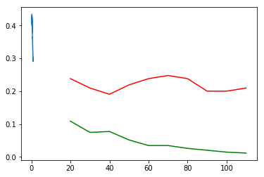

```python
x,y=get_data()
x_train,x_test_all,y_train,y_test_all=train_test_split(x,y,test_size=0.3,random_state=9)
x_dev,x_test,y_dev,y_test=train_test_split(x_test_all,y_test_all,test_size=0.3,random_state=9)

#构建单个模型
model=build_single_model(x_train,y_train)
predicted_y=model.predict(x_train)
print("\n Single Model Accuracy on training data\n")
print(classification_report(y_train,predicted_y))
print("Fraction of misclassfication = %0.2f" %(zero_one_loss(y_train,predicted_y)*100,),'%')

#构建多个模型
boosting=build_boosting_model(x_train,y_train)
predicted_y=boosting.predict(x_train)
print("\n Boosting Model Accuracy on training data\n")
print(classification_report(y_train,predicted_y))
print("Fraction of misclassification = %0.2f" %(zero_one_loss(y_train,predicted_y)*100),"%")
view_model(boosting)

#查看在Dev集上的运行情况
predicted_y=model.predict(x_dev)
print("\n Single Model Accuracy on Dev data\n")
print(classification_report(y_dev,predicted_y))
print("Fraction of misclassification = %0.2f" %(zero_one_loss(y_dev,predicted_y)*100),"%")

predicted_y=boosting.predict(x_dev)
print("\n Boosting Model Accuracy on Dev data\n")
print(classification_report(y_dev,predicted_y))
print("Fraction of misclassification = %0.2f" %(zero_one_loss(y_dev,predicted_y)*100),"%")

number_estimators_vs_err_rate(x_train,y_train,x_dev,y_dev)
```

## 理解集成——梯度提升

梯度提升法采用的是梯度，而不是权重来鉴别缺陷。以一个简单的回归问题为例，我们给定所需的预测器变量X和反应变量Y，这二者都是一个实数。$$X=\{x_1,x_2,....,x_n\} and Y=\{y_1,y_2,.....,y_n\}$$ 梯度法的执行步骤如下：

先从简单的模型开始，如平均值：$$\hat{y}=\frac{1}{N}\sum_{i=1}^{N}{y_i}$$ 预测值简单的设置为反应变量的平均值，接着开始调整残差，也就是真实值和预测值之间的误差$R_1=y-\hat{y}$

下一个分类器在如下的数据上进行训练$$\{(x_1,R_1),(x_2,R_2),....,(x_n,R_n)\}$$ 随后的模型在掐你个模型的残差上进行训练，就这样，算法持续的在集成中构建所需数量的模型。

现在来探究为什么要在残差上进行训练，到目前位置，我们清楚提升法创造了渐进的模型，假设我们构建了两个模型F1(X)和F2(X),来预测Y，依据渐进的原则，可以把两个模型组合成以下的形式$$F_1(X)+F_2(X)=Y_1$$ 也就是说这两个模型的预测值结合起来得到了预测值Y1.可以推导出等价的公式$$F_2(X)=Y_1-F_1(X)$$ 残差是模型没有完善处理的部分，简言之就是上一个模型的缺陷。因此我们可以利用残差来提升模型效果，也即改善上一个模型的缺陷

```
      Iter       Train Loss      OOB Improve   Remaining Time
         1          58.5196          20.8748            1.50s
         2          45.2833          10.3732            1.37s
         3          40.1522           8.8467            1.33s
         4          27.7772           8.2210            1.37s
         5          27.6316           3.9991            1.49s
         6          21.0990           4.0621            1.52s
         7          17.5833           2.8307            1.59s
         8          15.0893           2.3535            1.54s
         9          11.9637           1.8070            1.53s
        10          10.2020           1.4632            1.50s
        11           9.5262           0.7945            1.49s
        12           7.2975           0.6774            1.46s
        13           6.6403           0.4107            1.46s
        14           6.4880           0.2982            1.44s
        15           6.0600           0.2326            1.46s
        16           5.4829           0.0987            1.48s
        17           4.4872           0.4339            1.46s
        18           4.5728          -0.0933            1.46s
        19           4.4907          -0.1070            1.47s
        20           4.2713           0.1204            1.46s
        21           3.8139          -0.0294            1.46s
        22           4.0569           0.1370            1.47s
        23           3.2827          -0.1233            1.47s
        24           3.6827          -0.0219            1.46s
        25           3.3933           0.0265            1.45s
        26           3.0773           0.0355            1.44s
        27           2.9170          -0.0794            1.43s
        28           2.8000           0.0090            1.42s
        29           2.9376           0.0555            1.42s
        30           2.9341          -0.0120            1.42s
        31           2.7107          -0.0145            1.41s
        32           2.4329          -0.0825            1.41s
        33           2.2248          -0.0282            1.42s
        34           2.3968           0.0218            1.41s
        35           2.1704          -0.0340            1.41s
        36           2.4265          -0.0543            1.41s
        37           2.0856          -0.0292            1.40s
        38           1.9023          -0.0714            1.39s
        39           2.2966          -0.1218            1.38s
```

[output cut: 1056 more lines]

```
	 Feature 86 score 0.013
	 Feature 87 score 0.003
	 Feature 88 score 0.016
	 Feature 89 score 0.014
	 Feature 90 score 0.022
	 Feature 91 score 0.018
	 Feature 92 score 0.022

 Model Performance in Dev set(Polynomial features)

	Mean squared error = 11.10

 Model Performance in Test set(Polynomial features)

	Mean squared error = 9.05
```

```
9.054345951887365
```

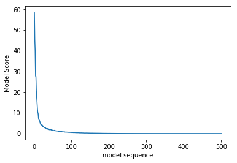

```python
from sklearn.datasets import load_boston
from sklearn.cross_validation import train_test_split
from sklearn.ensemble import GradientBoostingRegressor
from sklearn.metrics import mean_squared_error

from sklearn.preprocessing import PolynomialFeatures
import numpy as np
import matplotlib.pyplot as plt

def get_data():
    data=load_boston()
    x=data['data']
    y=data['target']
    return x,y

def build_model(x,y,n_estimators=500):
    """
    Build a Gradient Boost regression model
    """
    model = GradientBoostingRegressor(n_estimators=n_estimators,verbose=10,\
            subsample=0.7, learning_rate= 0.15,max_depth=3,random_state=77)
    model.fit(x,y)
    return model

def view_model(model):
    print("\n Training Scores")
    print("===================")
    for i,score in enumerate(model.train_score_):
        print("\t Estimator %d score %0.3f" %(i+1,score))
    plt.plot(range(1,model.estimators_.shape[0]+1),model.train_score_)
    plt.xlabel("model sequence")
    plt.ylabel("Model Score")
    print("\n Feature Importance ")
    print("=======================")
    for i,score in enumerate(model.feature_importances_):
        print("\t Feature %d score %0.3f" %(i+1,score))

def model_worth(true_y,predicted_y):
    print("\tMean squared error = %0.2f" %(mean_squared_error(true_y,predicted_y)))
    return mean_squared_error(true_y,predicted_y)

x,y=get_data()
x_train,x_test_all,y_train,y_test_all=train_test_split(x,y,test_size=0.3,random_state=9)
x_dev,x_test,y_dev,y_test=train_test_split(x_test_all,y_test_all,test_size=0.3,random_state=9)

#准备一些多项式特征
poly_features=PolynomialFeatures(2,interaction_only=True)
poly_features.fit(x_train)
x_train_poly=poly_features.transform(x_train)
x_dev_poly=poly_features.transform(x_dev)

#用多项式特征建模
model_poly=build_model(x_train_poly,y_train)
predicted_y=model_poly.predict(x_train_poly)
print("\n Model Performance in Training set(Polynomial features)\n")
model_worth(y_train,predicted_y)

#查看模型细节
view_model(model_poly)

#把模型应用到Dev集
predicted_y=model_poly.predict(x_dev_poly)
print("\n Model Performance in Dev set(Polynomial features)\n")
model_worth(y_dev,predicted_y)

#把模型应用到测试集中
x_test_poly=poly_features.transform(x_test)
predicted_y=model_poly.predict(x_test_poly)
print("\n Model Performance in Test set(Polynomial features)\n")
model_worth(y_test,predicted_y)
```

GradientBoostRegressor类的各参数意义：

- n_estimators是集成的模型数量
- verbose：当它被设置为大于1时，每个模型或者树构建时都会把进展情况打印出来
- subsample :指定了模型要采用的训练集数据量的百分比
- 学习率：这是一个缩减参数，用来控制每棵树的贡献
- Max_depth:决定了构建的树的大小

# 生长树

本章我们会介绍更多基于树算法的挂袋法相关内容。由于具备对抗噪音的健壮性和解决各类问题的广泛能力，他们在数据科学社区被广泛应用。这些方法赫赫有名是因为相较于其他方法，他们能够在没有数据整理的情况下获得很好的结果，也因为在软件工程师手中，他们能充当黑箱工具。除了上述好处，他们还具有更多的优点。

从设计上来说，挂袋法天然就能很好的并行运行，因此，这些方法可以很方便的应用到集群环境来处理很大的数据集

决策树算法在树的每一层上把输入数据划分为多个区域，这样就是先了隐式的特征选择，而特征选择是构建良好的模型最重要的步骤只有，拥有隐式的特征选择，决策树比其他技术更有优势，因此，挂袋法中包含的局的树也有这个优势。

决策树几乎不需要对数据进行任何的准备，例如不需要考虑对属性进行缩放，因为属性的度量对于决策树的结构没有影响，此外，缺失一些数据不影响决策树，异常点对决策树的影响也微乎其微。

当输入数据汇总存在非线性关系时，基于线性回归的模型就会失效，而基于树的算法则不受数据中非线性关系的影响。

基于树的方法的最大一个困扰就是为了避免过拟合而对数进行剪枝的难度，对于潜在在数据的噪声，大型的树倾向于受影响，导致偏差和高方差。不过，如果我们生成大量的树，最终的预测值采用集成里的所有树输出的平均值，就可以避免方差的问题

## 从生长树到生长森林——随机森林

随机森林会构建很多相互之间没有关联的树，给定一个分类或者回归问题，它构建许多树，最终的预测值对于回归问题是整个森林的预测值的平均值，对于分类则是一个多数表决。

这看起来跟挂袋法有点像，随机森林也就是一种挂袋方法，这种方法的基本思路是利用大量的噪声评估器，用平均法处理噪声，这样减少最终结果的方差。训练集中的微小噪声也会严重影响到树。因此，作为噪声评估器，它们在挂袋法中得有一个准则。

我们来写一下构建随机森林的步骤，用户得先指定森林中所需要的树的数量作为参数，这里用T表示。我们从1到T进行迭代，构建T棵树：

- 对于每棵树，从输入数据集中自举大小为D的样本
- 对于输入数据适配一棵树t：
  - 随机选择m个属性
  - 采用余弦定义好的标准，选择一个最佳属性用来作为划分变量
  - 将数据集划分为两个部分，记住，树天然就是二元划分的，在树的每一层上，输入数据集都被一分为二
  - 在名为划分的数据集上得带执行上面上面的三个步骤
- 最后返回树T

对于分类问题的新实例，要做出一个预测值，需要在T中的所有树里做出多数表决；对于回归问题，我们去T里的每个树t返回的平均值

之前提到过的，随机森林构建的是相互之间没有关联的树，我们来看看为何在集成这么多树相互之间都没有关联。从数据集中自举给样本给每棵树， 我们确信数据的不同部分出现在不同的树上，这样每棵树为数据集的不同特征建模，因此我们要坚持集成的原则王潜在的评估器中引入方差。不过，这样并不能保证在不同的树之间完全没有关联。在进行节点划分的时候，我们不能选择所有的属性，而是随机选择一个属性的子集，这样就能确保任何树之间没有相互关联。

提升法中集成的评估器是弱分类器，与之相比，我们在随机森林中构建最大深度的树，这样他们可以很好适应自举的样本，得到的偏差较低，后果是引入了高方差，不过通过构建大量的树，使用平均法则作为最后的预测值，我们有希望解决方差问题

```python
from sklearn.datasets import make_classification
from sklearn.metrics import classification_report,accuracy_score
from sklearn.cross_validation import train_test_split
from sklearn.ensemble import RandomForestClassifier
from sklearn.grid_search import RandomizedSearchCV
from operator import itemgetter
import numpy as np

def get_data():
    x,y=make_classification(n_samples=500,n_features=30,flip_y=0.3,n_informative=18,n_redundant=3,n_repeated=3,random_state=7)
    return x,y

def build_forest(x,y,x_dev,y_dev):
    estimator=RandomForestClassifier(n_estimators=100)
    estimator.fit(x,y)

    train_predicted=estimator.predict(x)
    train_score=accuracy_score(y,train_predicted)
    dev_predicted=estimator.predict(x_dev)
    dev_score=accuracy_score(y_dev,dev_predicted)

    print("\n Training accuracy = %0.2f  Dev Accuracy =%0.2f" %(train_score,dev_score))

def search_parameters(x,y,x_dev,y_dev):
    estimator=RandomForestClassifier()
    no_features=x.shape[1]
    no_iteration=20
    sqr_no_features=int(np.sqrt(no_features))
    parameters={"n_estimators":np.random.randint(75,200,no_iteration),
               "criterion":['gini',"entropy"],
                "max_features":[sqr_no_features,sqr_no_features*2,sqr_no_features*3,sqr_no_features+10]
               }
    grid=RandomizedSearchCV(estimator=estimator,param_distributions=parameters,verbose=1,
                            n_iter=no_iteration,random_state=77,n_jobs=-1,cv=5)
    grid.fit(x,y)
    print_model_worth(grid,x_dev,y_dev)
    return grid.best_estimator_

def print_model_worth(grid,x_dev,y_dev):
    scores=sorted(grid.grid_scores_,key=itemgetter(1),reverse=True)[0:5]
    for model_no,score in enumerate(scores):
        print("Model %d Score=%0.2f "%(model_no+1,score.mean_validation_score))
        print("Parameters={0}".format(score.parameters))
    dev_predicted=grid.predict(x_dev)
    print(classification_report(y_dev,dev_predicted))

def get_feature_importance(model):
    feature_importance = model.feature_importances_
    fm_with_id = [(i,importance) for i,importance in enumerate(feature_importance)]
    fm_with_id = sorted(fm_with_id, key=itemgetter(1),reverse=True)[0:10]
    print("Top 10 Features")
    for importance in fm_with_id:
        print("Feature %d importance = %0.3f"%(importance[0],importance[1]))
```

```python
x,y=get_data()
x_train,x_test_all,y_train,y_test_all=train_test_split(x,y,test_size=0.3,random_state=9)
x_dev,x_test,y_dev,y_test=train_test_split(x_test_all,y_test_all,test_size=0.3,random_state=9)

build_forest(x_train,y_train,x_dev,y_dev)
model=search_parameters(x,y,x_dev,y_dev)
get_feature_importance(model)
```

```
 Training accuracy = 1.00  Dev Accuracy =0.70
Fitting 5 folds for each of 20 candidates, totalling 100 fits
```

```
[Parallel(n_jobs=-1)]: Done  42 tasks      | elapsed:   11.4s
[Parallel(n_jobs=-1)]: Done 100 out of 100 | elapsed:   27.6s finished
```

```
Model 1 Score=0.77
Parameters={'n_estimators': 121, 'max_features': 10, 'criterion': 'gini'}
Model 2 Score=0.77
Parameters={'n_estimators': 117, 'max_features': 5, 'criterion': 'gini'}
Model 3 Score=0.76
Parameters={'n_estimators': 121, 'max_features': 5, 'criterion': 'gini'}
Model 4 Score=0.76
Parameters={'n_estimators': 195, 'max_features': 10, 'criterion': 'entropy'}
Model 5 Score=0.76
Parameters={'n_estimators': 82, 'max_features': 10, 'criterion': 'entropy'}
             precision    recall  f1-score   support

          0       1.00      1.00      1.00        49
          1       1.00      1.00      1.00        56

avg / total       1.00      1.00      1.00       105

Top 10 Features
Feature 11 importance = 0.084
Feature 1 importance = 0.080
Feature 5 importance = 0.057
Feature 15 importance = 0.057
Feature 19 importance = 0.044
Feature 6 importance = 0.039
Feature 14 importance = 0.036
Feature 17 importance = 0.036
Feature 22 importance = 0.035
Feature 24 importance = 0.035
```

## 生成超随机树

超随机树也叫超树算法，它和上一节介绍的随机森林的不同之处在于以下两个方面：

1. 它不用自举法来给集成的每棵树选择实例，而是使用完整的训练集数据
2. 给定K作为在给定节点随机选择的属性数量，它随机选择割点，不考虑目标变量

上一节提到的的随机森林在两处使用随机化，第一处是在选择实例来训练森林里的树时，使用了自举法进行选择；第二处是在每个节点上随机选择属性的集合，每个被选中的属性是基于其基尼不纯度或者熵标准。**超随机树更进一步，完全随机的选择用来划分数据的属性**

超树方法背后的原理是这样的：相比于彩玉其他方法的弱随机架构，它的割点显式随机化和属性组合的总体平均都可以用来更好的降低方差。和随机森林相比，超随机树把割点（在每个节点上选择用来划分数据集的属性）的随机化组合起来，忽略任何标准，最后将每棵树的结果进行平均，这样在未知的数据集上可以得到非常好的效果

第二个优势与计算复杂度有关。从计算的角度来看，生长树的过程——假定是平衡树，和其他树的生长过程一样，复杂度是O（NlogN），和采样的大小相关。然而，给定划分节点过程的简单程度，我们期望常数因子能远小于其他在本地进行割点优化的集成方法

因为不需要花费时间来鉴别最合适用来划分数据集的属性，这个方法比随机森林在计算效率上要高很多。

我们写一下构建随机树的步骤，用户得先指定森林所需要的树的数量作为参数，这里有用T表示。我们从1到T执行迭代，也就是构建T棵树

- 对于每棵树，选择所有的输入数据
- 对输入数据适配每一棵树t.
  - 随机选择m个属性
  - 随机选择一个属性作为划分变量
  - 将数据集划分为两个部分，树是天然二元划分的，在树的每一层上，输入数据集都被一分为二
  - 在我们划分的数据集上迭代执行上述三个步骤
- 最后，返回树T

```python
from sklearn.datasets import make_classification
from sklearn.metrics import classification_report,accuracy_score
from sklearn.cross_validation import train_test_split,cross_val_score
from sklearn.ensemble import ExtraTreesClassifier
from sklearn.grid_search import RandomizedSearchCV
from operator import itemgetter
import numpy as np

def get_data():
    x,y=make_classification(n_samples=500,n_features=30,flip_y=0.3,n_informative=18,n_redundant=3,n_repeated=3,random_state=7)
    return x,y

def build_forest(x,y,x_dev,y_dev):
    estimator=ExtraTreesClassifier(n_estimators=100,random_state=51)
    estimator.fit(x,y)

    train_predicted=estimator.predict(x)
    train_score=accuracy_score(y,train_predicted)
    dev_predicted=estimator.predict(x_dev)
    dev_score=accuracy_score(y_dev,dev_predicted)

    print("\n Training accuracy = %0.2f  Dev Accuracy =%0.2f" %(train_score,dev_score))
    print("Cross Validated Score")
    print(cross_val_score(estimator,x_dev,y_dev,cv=5))

def search_parameters(x,y,x_dev,y_dev):
    estimator=ExtraTreesClassifier()
    no_features=x.shape[1]
    no_iteration=20
    sqr_no_features=int(np.sqrt(no_features))
    parameters={"n_estimators":np.random.randint(75,200,no_iteration),
               "criterion":['gini',"entropy"],
                "max_features":[sqr_no_features,sqr_no_features*2,sqr_no_features*3,sqr_no_features+10]
               }
    grid=RandomizedSearchCV(estimator=estimator,param_distributions=parameters,verbose=1,
                            n_iter=no_iteration,random_state=77,n_jobs=-1,cv=5)
    grid.fit(x,y)
    print_model_worth(grid,x_dev,y_dev)
    return grid.best_estimator_

x,y=get_data()
x_train,x_test_all,y_train,y_test_all=train_test_split(x,y,test_size=0.3,random_state=9)
x_dev,x_test,y_dev,y_test=train_test_split(x_test_all,y_test_all,test_size=0.3,random_state=9)

build_forest(x_train,y_train,x_dev,y_dev)
model=search_parameters(x,y,x_dev,y_dev)
```

```
 Training accuracy = 1.00  Dev Accuracy =0.76
Cross Validated Score
[0.77272727 0.76190476 0.66666667 0.71428571 0.65      ]
Fitting 5 folds for each of 20 candidates, totalling 100 fits
```

```
[Parallel(n_jobs=-1)]: Done  42 tasks      | elapsed:    7.1s
[Parallel(n_jobs=-1)]: Done 100 out of 100 | elapsed:   13.7s finished
```

```
Model 1 Score=0.79
Parameters={'n_estimators': 173, 'max_features': 15, 'criterion': 'gini'}
Model 2 Score=0.78
Parameters={'n_estimators': 86, 'max_features': 10, 'criterion': 'entropy'}
Model 3 Score=0.78
Parameters={'n_estimators': 77, 'max_features': 5, 'criterion': 'gini'}
Model 4 Score=0.78
Parameters={'n_estimators': 169, 'max_features': 15, 'criterion': 'entropy'}
Model 5 Score=0.78
Parameters={'n_estimators': 163, 'max_features': 15, 'criterion': 'gini'}
             precision    recall  f1-score   support

          0       1.00      1.00      1.00        49
          1       1.00      1.00      1.00        56

avg / total       1.00      1.00      1.00       105
```

## 生成旋转森林

随机森林和挂袋法在大量集成是，能够得到让人印象深刻的效果，树类方法如果有大量评估器，就鞥你在精度方面得到提高。与此不同，旋转森林的设计思路是采用少得多的集成数量。

我们来写一下构建旋转森林的步骤，用户首先得指定森林中所需要的树的数量作为参数，这里用T表示，从1到T进行迭代，也就是构建T棵树。对于每棵树t，执行以下步骤：

- 将训练集里的属性划分为大小相等的K个不重叠的子集
- 现在我们有K个数据集，每个有K个属性，对于每份数据集，我们执行以下操作：自举75%的数据，对于这些自举得到的样本执行以下步骤： -在K个数据集的第i个子集中进行主成分分析，保留所有主成分。对第K个子集的每个特征j，我们得到一个主成分a,表示为$a_{ij}$,就是第i个子集的第j个属性的主成分。
  - 保留以上所有子集的主成分
- 创建一个n*n的旋转矩阵，n是属性总数，将主成分放入矩阵中，这些成分匹配特征在初始训练数据集中位置
- 与矩阵乘法将训练集投射到旋转矩阵上
- 用投射的数据构建一个棵决策树
- 保存树和旋转矩阵

```python
from sklearn.datasets import make_classification
from sklearn.metrics import classification_report,accuracy_score
from sklearn.cross_validation import train_test_split
from sklearn.decomposition import PCA
from sklearn.tree import DecisionTreeClassifier
import numpy as np


def get_data():
    x,y=make_classification(n_samples=500,n_features=30,flip_y=0.3,n_informative=18,n_redundant=3,n_repeated=3,random_state=7)
    return x,y

def get_random_subset(iterabel,k):
    subsets=[]
    iteration=0
    np.random.shuffle(iterabel)
    subset=0
    limit=len(iterabel)/k
    while iteration < limit:
        if k <= len(iterabel):
            subset=k
        else:
            subset=len(iterabel)
        subsets.append(iterabel[-subset:])
        del iterabel[-subset:]
        iteration+=1
    return subsets

def build_rotationtree_model(x_train,y_train,d,k):
    models=[]
    r_metrices=[]
    feature_subsets=[]
    for i in range(d):
        x,_,_,_=train_test_split(x_train,y_train,test_size=0.3,random_state=7)
        feature_index=[i for i in range(x.shape[1])]
        random_k_subset=get_random_subset(feature_index,k)
        feature_subsets.append(random_k_subset)
        #旋转矩阵
        R_metrix=np.zeros((x.shape[1],x.shape[1]),dtype=float)
        for each_subset in random_k_subset:
            pca=PCA()
            x_subset=x[:,each_subset]
            pca.fit(x_subset)
            for ii in range(0,len(pca.components_)):
                for jj in range(0,len(pca.components_)):
                    R_metrix[each_subset[ii],each_subset[jj]]=pca.components_[ii,jj]
        x_transformed=x_train.dot(R_metrix)

        model=DecisionTreeClassifier()
        model.fit(x_transformed,y_train)
        models.append(model)
        r_metrices.append(R_metrix)
    return models,r_metrices,feature_subsets

def model_worth(models,r_metrices,x,y):
    predicted_ys=[]
    for i,model in enumerate(models):
        x_mod=x.dot(r_metrices[i])
        predicted_y=model.predict(x_mod)
        predicted_ys.append(predicted_y)
    predicted_metrix=np.asmatrix(predicted_ys)
    final_prediction=[]
    for i in range(len(y)):
        pred_from_all_models=np.ravel(predicted_metrix[:i])
        non_zero_pred=np.nonzero(pred_from_all_models)[0]
        is_one=len(non_zero_pred)>len(models)/2
        final_prediction.append(is_one)
    print(classification_report(y,final_prediction))


x,y=get_data()
x_train,x_test_all,y_train,y_test_all=train_test_split(x,y,test_size=0.3,random_state=9)
x_dev,x_test,y_dev,y_test=train_test_split(x_test_all,y_test_all,test_size=0.3,random_state=9)

models,r_metrices,features=build_rotationtree_model(x_train,y_train,25,5)
model_worth(models,r_metrices,x_train,y_train)
model_worth(models,r_metrices,x_dev,y_dev)
```

```
             precision    recall  f1-score   support

          0       1.00      0.01      0.01       189
          1       0.46      1.00      0.63       161

avg / total       0.75      0.46      0.30       350

             precision    recall  f1-score   support

          0       1.00      0.02      0.04        49
          1       0.54      1.00      0.70        56

avg / total       0.75      0.54      0.39       105
```

# 大规模机器学习——在线学习

到目前为止，我们所训练的模型都被限定为可以完全装在到计算机内存里，这里讲介绍如何在不满足这个条件的情况下，如何建模。训练集记录数目庞大，无法完全装载到计算机内存中，只能分段加载，同时还要保持模型精度良好。**训练街无法全部加载到内存的情形可以外推到流数据，在此情况下，我们无法立刻看到数据的全貌，无论接触到的数据是什么样，我们都应该能做出判断，并构建一个随新数据到来而持续提高的架构。**

## 用感知器作为在线学习算法

我们审视一下分类问题的定义：对于每个记录或者实例，它可以表示成为集合（X,y），其中X的一系列属性，y则是相应的类别标签。学习一个目标函数F，然后把每个记录的属性集合映射到一个预定义的类别标签y上，这就是分类算法。现在的情况有所不同：我们面对的是大规模的学习问题，无法将数据完全加载到内存中，因此我们必须把数据存放到磁盘中，感知器建模的一段时间只使用其中的一部分。感知器算法的大致步骤如下所示：

1. 将模型的权重用一个小的随机数进行初始化
2. 用输入数据x的平均值进行中心化
3. 在每个步骤t(也称为纪元)：
   - 将数据集搅乱
   - 选择记录中的一个实例并进行预测
   - 观察预测的和真实的标签输出，比较其误差
   - 预测值如果与真实值不同，则更新权重

想像一下如下场景：磁盘上有完整的数据集，在每个纪元里，也就是上述第三步中提到的每个操作执行遍历磁盘上的所有数据。在一个在线学习场景中，任一时间点上都有一群基于窗口函数的实例是可用的。在每一个纪元中，我们更新权重的次数和窗口时间里的实例数量一样多。我们来看一下如何更新权重：

假定输入X如下：$$X_i=\{x_1,x_2,...,x_m\} where i=1 to n $$ Y的集合如下：$$Y=\{+1,-1\}$$ 权重的定义方程如下：$$W=\{w_1,w_2,...,w_m\}$$ 每条记录得出的预测值定义如下：$$\hat{y_i}=sign(w_i*x_i)$$ 如果权重和属性的乘积是正数，sign函数返回+1，如果是负数，返回-1。感知器对预测的y值和真实的y值进行比较，如果预测的y是正确的，则处理下一条记录，否则的话有两种情况：如果预测值为+1，而真实值是-1，它用x值降低权重；反之亦然，如果真实值为+1，而预测值为-1，它提高权重。我们用下面等式可以看得更清楚些：$$w_{t+1}=w_t+y_ix_i$$ 一般来说，算法提供一个学习速率参数alpha，这样权重更新的过程可以受控。在数据中有噪音时，全面增加衰减会导致权重不能收敛。$$w_{t+1}=w_t+\alpha(y_ix_i)$$ alpha的取值很小，一般介于0.1到0.4之间

```python
from sklearn.datasets import make_classification
from sklearn.metrics import classification_report
from sklearn.preprocessing import scale
import numpy as np

def get_data(batch_size):
    b_size=0
    no_features=30
    while b_size<batch_size:
        x,y=make_classification(n_samples=1000,n_features=no_features,flip_y=0.3,
                               n_informative=24,n_redundant=3,n_repeated=3,random_state=51)
        y_index=y<1
        y[y_index]=-1
        x=scale(x,with_mean=True,with_std=True)
        yield x,y
        b_size+=1

def build_model(x,y,weights,epochs,alpha=0.5):
    for i in range(epochs):
        shuff_index=np.random.shuffle([i for i in range(len(y))])
        x_train=x[shuff_index,:].reshape(x.shape)
        y_train=np.ravel(y[shuff_index,:])
        for  index in range(len(y)):
            prediction=np.sign(np.sum(x_train[index,:]*weights))
            if prediction != y_train[index]:
                weights=weights+alpha*(y_train[index]*x_train[index,:])
    return weights

def model_worth(x,y,weights):
    prediction=np.sign(np.sum(x*weights,axis=1))
    print(classification_report(y,prediction))
```

```python
data=get_data(10)
x,y=next(data)
weights=np.zeros(x.shape[1])
for i in range(10):
    epochs=100
    weights=build_model(x,y,weights,epochs)
    print("model worth after receiving dataset batch %d"%(i+1))
    model_worth(x,y,weights)
    if i<9:
        x,y=next(data)
```

```
model worth after receiving dataset batch 1
             precision    recall  f1-score   support

         -1       0.61      0.61      0.61       489
          1       0.62      0.62      0.62       511

avg / total       0.62      0.61      0.62      1000

model worth after receiving dataset batch 2
             precision    recall  f1-score   support

         -1       0.57      0.59      0.58       489
          1       0.59      0.57      0.58       511

avg / total       0.58      0.58      0.58      1000

model worth after receiving dataset batch 3
             precision    recall  f1-score   support

         -1       0.60      0.61      0.61       489
          1       0.62      0.61      0.61       511

avg / total       0.61      0.61      0.61      1000

model worth after receiving dataset batch 4
             precision    recall  f1-score   support

         -1       0.59      0.62      0.61       489
          1       0.62      0.60      0.61       511

avg / total       0.61      0.61      0.61      1000

model worth after receiving dataset batch 5
             precision    recall  f1-score   support

         -1       0.61      0.62      0.61       489
          1       0.63      0.62      0.62       511

avg / total       0.62      0.62      0.62      1000

```

[output cut: 24 more lines]

```
model worth after receiving dataset batch 9
             precision    recall  f1-score   support

         -1       0.58      0.60      0.59       489
          1       0.60      0.58      0.59       511

avg / total       0.59      0.59      0.59      1000

model worth after receiving dataset batch 10
             precision    recall  f1-score   support

         -1       0.59      0.61      0.60       489
          1       0.62      0.60      0.61       511

avg / total       0.61      0.60      0.61      1000
```

## 用随机梯度下降解决回归问题

在标准的回归结构里，我们有一系列的预测器，形式如下$$X=\{x_1,x_2,....,x_n\}$$ 每个实例有m个属性，形式如下：$$X_i=\{x_{i1},x_{i2},....,x_{im}\}$$ 反应变量Y是一个由实数条目组成的向量，回归算法的任务是找到一个函数，当x作为它的输入时，能返回y。$$F(X)=Y$$ 上面这个函数有一个权重向量来参数化，也即权重向量和输入向量组合起来预测y值，因此，可以在公式中加入权重向量，形式如下。$$F(X,W)=Y$$ 这样问题就变成了如何才能得到合适的权重向量，我们采用损失函数L来解决这个问题。损失函数用来衡量预测出错所付出的代价，它凭经验测算预测值和真实值y之间的差距。回归问题现在转化为找出让损失函数最小的合适的权重向量。对于有n个元素的数据集，全局损失函数的形式如下：$$\frac{1}{n}\sum_{i=1}^{n}{L(f(x_i,w),y_i}$$ 我们所要找的权重向量要使得上是最小。梯度下降法是一种优化技术，用来使得上述式子的值最小，对于整个式子，我们要找出其梯度，也就是对W的一阶导数。和批量梯度下降等优化技术不同，随机梯度下降每次只操作一个实例，它的操作步骤如下：

1. 对于每个纪元，搅乱数据集
2. 选择一个实例及它对应的反应变量y
3. 计算损失函数和它关于权重的导数
4. 更新权重值

我们定义一个符号：$\bigtriangledown_w$，它代表了关于w的导数，权重更新的公式如下所示：$$w_{i+1}=w_i-\bigtriangledown_wL(f(x_i,w),y_i)$$ 如你所见，权重和梯度的方向相反，强制使得最终权重向量降序排列，这样能减少目标代价函数。回归问题中经常用损失的平方作为损失函数，它的公式如下。$$(\hat{y}-y)^2$$ 上式的导数可以替换到权重更新公式里。在介绍感知器时曾提到过，为了避免噪音影响效果，引入了学习速率$\eta$到权重更新公式里$$w_{i+1}=w_i-\eta(\bigtriangledown_w L(f(x_i,w),y_i)$$

```python
from sklearn.datasets import make_regression
from sklearn.linear_model import SGDRegressor
from sklearn.metrics import mean_absolute_error,mean_squared_error
from sklearn.cross_validation import train_test_split

def get_data():
    x,y=make_regression(n_samples=1000,n_features=30,random_state=51)
    return x,y

def build_model(x,y):
    estimator=SGDRegressor(n_iter=10,shuffle=True,loss="squared_loss",learning_rate='constant',
                           eta0=0.01,fit_intercept=True,penalty='none')
    estimator.fit(x,y)
    return estimator

def model_worth(model,x,y):
    predicted_y=model.predict(x)
    print("\nMean absolute error =%0.2f" %(mean_absolute_error(y,predicted_y)))
    print("\nMean squared error =%0.2f" %(mean_squared_error(y,predicted_y)))

def inspect_model(model):
    print('\nModel Itercept {0}'.format(model.intercept_))
    for i,coef in enumerate(model.coef_):
        print("Coefficient {0}={1:.3f}".format(i+1,coef))
```

```python
x,y=get_data()
x_train,x_test_all,y_train,y_test_all=train_test_split(x,y,test_size=0.3,random_state=9)
x_dev,x_test,y_dev,y_test=train_test_split(x_test_all,y_test_all,test_size=0.3,random_state=9)

model=build_model(x_train,y_train)
inspect_model(model)
print("Model worth on train data")
model_worth(model,x_train,y_train)
print('model on dev data')
model_worth(model,x_dev,y_dev)
```

```
Model Itercept [-3.56353021e-15]
Coefficient 1=41.826
Coefficient 2=-0.000
Coefficient 3=73.811
Coefficient 4=0.000
Coefficient 5=0.000
Coefficient 6=58.613
Coefficient 7=-0.000
Coefficient 8=0.000
Coefficient 9=-0.000
Coefficient 10=0.000
Coefficient 11=9.147
Coefficient 12=-0.000
Coefficient 13=-0.000
Coefficient 14=63.520
Coefficient 15=0.000
Coefficient 16=-0.000
Coefficient 17=0.000
Coefficient 18=0.000
Coefficient 19=-0.000
Coefficient 20=-0.000
Coefficient 21=98.782
Coefficient 22=3.832
Coefficient 23=0.000
Coefficient 24=99.239
Coefficient 25=-0.000
Coefficient 26=0.000
Coefficient 27=0.000
Coefficient 28=56.245
Coefficient 29=-0.000
Coefficient 30=84.775
Model worth on train data

Mean absolute error =0.00

Mean squared error =0.00
model on dev data

Mean absolute error =0.00

Mean squared error =0.00
```

我们还可以正则化加入到随机梯度下降框架中，回顾之前前面所提到过的代价函数$$\sum_{i=1}^{n}{(y_i-w_0-\sum_{j=1}^{m}{x_{ij}w_{ij}})^2}+\alpha\sum_{j=1}^{m}{w_{j}^2}$$ 加入一个平方损失函数的扩展版，再加上正则化项——权重的平方和，把这些都加到梯度下降的过程中，设定R(W)表示正则化项，现在权重更新的公式如下$$w_{i+1}=w_i-\eta(\bigtriangledown L(f(x_i,w),y_i)+\alpha(\bigtriangledown R(w)))$$ 如你所见，现在的公式里包含了关于权重向量w的损失函数的导数，还有关于权重更新的正则化项的导数也出现在权重更新规则里。

```python
def build_regularize_model(x,y):
    estimator=SGDRegressor(n_iter=10,shuffle=True,loss="squared_loss",learning_rate='constant',
                           eta0=0.01,fit_intercept=True,penalty='l2',alpha=0.01)
    estimator.fit(x,y)
    return estimator
mode=build_regularize_model(x_train,y_train)
inspect_model(model)
print("Model worth on train data")
model_worth(model,x_train,y_train)
print('model on dev data')
model_worth(model,x_dev,y_dev)
```

[output not shown]

## 用随机梯度下降解决分类问题

分类问题除了反应变量不同，其他结构都和回归问题类似。分类问题结构中，反应变量是分类变量，由于其自身性质，我们需要不一样的损失函数来评估错误预测的代价。这里的讨论仅限于二元分类问题，目标变量的取值范围为{0,1}。为了得到合适的权重向量，我们在更新权重规则里使用损失函数的导数。对于如下形式的数据，逻辑回归能适配线性模型：$$W^TX$$